# Risk Factor Analysis

## Outcome Variable

**Outcome Variable:** ever_stunted

## Predictor Variables

**Intervention Variable:** fage

**Adjustment Set:**

unadjusted

## Stratifying Variables

The analysis was stratified on these variable(s):

- agecat
- studyid

The following strata were considered:

- agecat: 12 months, studyid: ki0047075b-MAL-ED
- agecat: 12 months, studyid: ki1000304b-SAS-FoodSuppl
- agecat: 12 months, studyid: ki1135781-COHORTS
- agecat: 12 months, studyid: ki1148112-LCNI-5
- agecat: 18 months, studyid: ki0047075b-MAL-ED
- agecat: 18 months, studyid: ki1000304b-SAS-FoodSuppl
- agecat: 18 months, studyid: ki1135781-COHORTS
- agecat: 18 months, studyid: ki1148112-LCNI-5
- agecat: 24 months, studyid: ki0047075b-MAL-ED
- agecat: 24 months, studyid: ki1000304b-SAS-FoodSuppl
- agecat: 24 months, studyid: ki1135781-COHORTS
- agecat: 24 months, studyid: ki1148112-LCNI-5
- agecat: 3 months, studyid: ki0047075b-MAL-ED
- agecat: 3 months, studyid: ki1135781-COHORTS
- agecat: 6 months, studyid: ki0047075b-MAL-ED
- agecat: 6 months, studyid: ki1000304b-SAS-FoodSuppl
- agecat: 6 months, studyid: ki1135781-COHORTS
- agecat: 6 months, studyid: ki1148112-LCNI-5

### Dropped Strata

Some strata were dropped due to rare outcomes:

- agecat: 6 months, studyid: ki1148112-LCNI-5
- agecat: 12 months, studyid: ki0047075b-MAL-ED
- agecat: 12 months, studyid: ki1000304b-SAS-FoodSuppl
- agecat: 12 months, studyid: ki1148112-LCNI-5
- agecat: 18 months, studyid: ki0047075b-MAL-ED
- agecat: 18 months, studyid: ki1000304b-SAS-FoodSuppl
- agecat: 18 months, studyid: ki1148112-LCNI-5
- agecat: 24 months, studyid: ki0047075b-MAL-ED
- agecat: 24 months, studyid: ki1000304b-SAS-FoodSuppl
- agecat: 24 months, studyid: ki1148112-LCNI-5

## Methods Detail

We’re interested in the causal parameters $E[Y_a]$ for all values of $a \in \mathcal{A}$. These parameters represent the mean outcome if, possibly contrary to fact, we intervened to set all units to have $A=a$. Under the randomization and positivity assumptions, these are identified by the statistical parameters $\psi_a=E_W[E_{Y|A,W}(Y|A=a,W)]$. In addition, we’re interested in the mean of $Y$, $E[Y]$ under no intervention (the observed mean). We will estimate these parameters by using SuperLearner to fit the relevant likelihood factors – $E_{Y|A,W}(Y|A=a,W)$ and $p(A=a|W)$, and then updating our likelihood fit using a joint TMLE.

For unadjusted analyses ($W=\{\}$), initial likelihoods were estimated using Lrnr_glm to estimate the simple $E(Y|A)$ and Lrnr_mean to estimate $p(A)$. For adjusted analyses, a small library containing Lrnr_glmnet, Lrnr_xgboost, and Lrnr_mean was used.

Having estimated these parameters, we will then use the delta method to estimate relative risks and attributable risks relative to a prespecified baseline level of $A$.

# Results Detail

## Results Plots

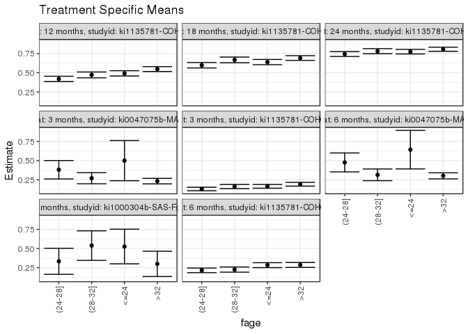

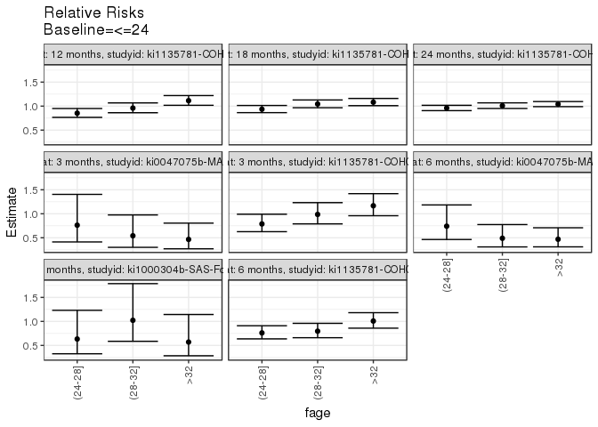

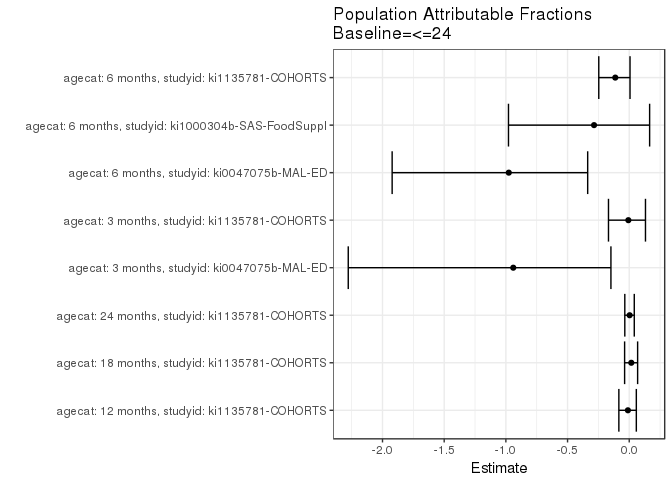

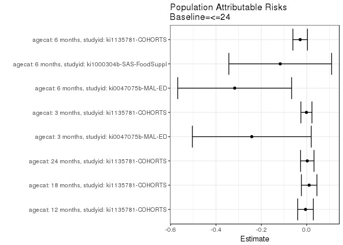

## Data Summary

| agecat | studyid | A | n | nA | nAY0 | nAY1 |
| --- | --- | --- | --- | --- | --- | --- |
| 3 months | ki0047075b-MAL-ED | <=24 | 745 | 14 | 7 | 7 |
| 3 months | ki0047075b-MAL-ED | (24-28] | 745 | 63 | 39 | 24 |
| 3 months | ki0047075b-MAL-ED | (28-32] | 745 | 144 | 105 | 39 |
| 3 months | ki0047075b-MAL-ED | >32 | 745 | 524 | 402 | 122 |
| 3 months | ki1000304b-SAS-FoodSuppl | <=24 | 0 | 0 | 0 | 0 |
| 3 months | ki1000304b-SAS-FoodSuppl | (24-28] | 0 | 0 | 0 | 0 |
| 3 months | ki1000304b-SAS-FoodSuppl | (28-32] | 0 | 0 | 0 | 0 |
| 3 months | ki1000304b-SAS-FoodSuppl | >32 | 0 | 0 | 0 | 0 |
| 3 months | ki1135781-COHORTS | <=24 | 3441 | 886 | 740 | 146 |
| 3 months | ki1135781-COHORTS | (24-28] | 3441 | 847 | 737 | 110 |
| 3 months | ki1135781-COHORTS | (28-32] | 3441 | 720 | 603 | 117 |
| 3 months | ki1135781-COHORTS | >32 | 3441 | 988 | 798 | 190 |
| 3 months | ki1148112-LCNI-5 | <=24 | 0 | 0 | 0 | 0 |
| 3 months | ki1148112-LCNI-5 | (24-28] | 0 | 0 | 0 | 0 |
| 3 months | ki1148112-LCNI-5 | (28-32] | 0 | 0 | 0 | 0 |
| 3 months | ki1148112-LCNI-5 | >32 | 0 | 0 | 0 | 0 |
| 6 months | ki0047075b-MAL-ED | <=24 | 744 | 14 | 5 | 9 |
| 6 months | ki0047075b-MAL-ED | (24-28] | 744 | 63 | 33 | 30 |
| 6 months | ki0047075b-MAL-ED | (28-32] | 744 | 143 | 98 | 45 |
| 6 months | ki0047075b-MAL-ED | >32 | 744 | 524 | 366 | 158 |
| 6 months | ki1000304b-SAS-FoodSuppl | <=24 | 105 | 19 | 9 | 10 |
| 6 months | ki1000304b-SAS-FoodSuppl | (24-28] | 105 | 30 | 20 | 10 |
| 6 months | ki1000304b-SAS-FoodSuppl | (28-32] | 105 | 26 | 12 | 14 |
| 6 months | ki1000304b-SAS-FoodSuppl | >32 | 105 | 30 | 21 | 9 |
| 6 months | ki1135781-COHORTS | <=24 | 2851 | 755 | 541 | 214 |
| 6 months | ki1135781-COHORTS | (24-28] | 2851 | 728 | 571 | 157 |
| 6 months | ki1135781-COHORTS | (28-32] | 2851 | 598 | 463 | 135 |
| 6 months | ki1135781-COHORTS | >32 | 2851 | 770 | 550 | 220 |
| 6 months | ki1148112-LCNI-5 | <=24 | 18 | 2 | 1 | 1 |
| 6 months | ki1148112-LCNI-5 | (24-28] | 18 | 4 | 3 | 1 |
| 6 months | ki1148112-LCNI-5 | (28-32] | 18 | 3 | 2 | 1 |
| 6 months | ki1148112-LCNI-5 | >32 | 18 | 9 | 6 | 3 |
| 12 months | ki0047075b-MAL-ED | <=24 | 743 | 14 | 3 | 11 |
| 12 months | ki0047075b-MAL-ED | (24-28] | 743 | 62 | 26 | 36 |
| 12 months | ki0047075b-MAL-ED | (28-32] | 743 | 143 | 77 | 66 |
| 12 months | ki0047075b-MAL-ED | >32 | 743 | 524 | 309 | 215 |
| 12 months | ki1000304b-SAS-FoodSuppl | <=24 | 99 | 18 | 2 | 16 |
| 12 months | ki1000304b-SAS-FoodSuppl | (24-28] | 99 | 26 | 5 | 21 |
| 12 months | ki1000304b-SAS-FoodSuppl | (28-32] | 99 | 27 | 5 | 22 |
| 12 months | ki1000304b-SAS-FoodSuppl | >32 | 99 | 28 | 3 | 25 |
| 12 months | ki1135781-COHORTS | <=24 | 3211 | 814 | 414 | 400 |
| 12 months | ki1135781-COHORTS | (24-28] | 3211 | 785 | 456 | 329 |
| 12 months | ki1135781-COHORTS | (28-32] | 3211 | 662 | 350 | 312 |
| 12 months | ki1135781-COHORTS | >32 | 3211 | 950 | 430 | 520 |
| 12 months | ki1148112-LCNI-5 | <=24 | 47 | 7 | 3 | 4 |
| 12 months | ki1148112-LCNI-5 | (24-28] | 47 | 11 | 7 | 4 |
| 12 months | ki1148112-LCNI-5 | (28-32] | 47 | 10 | 6 | 4 |
| 12 months | ki1148112-LCNI-5 | >32 | 47 | 19 | 10 | 9 |
| 18 months | ki0047075b-MAL-ED | <=24 | 743 | 14 | 2 | 12 |
| 18 months | ki0047075b-MAL-ED | (24-28] | 743 | 62 | 22 | 40 |
| 18 months | ki0047075b-MAL-ED | (28-32] | 743 | 143 | 60 | 83 |
| 18 months | ki0047075b-MAL-ED | >32 | 743 | 524 | 242 | 282 |
| 18 months | ki1000304b-SAS-FoodSuppl | <=24 | 93 | 16 | 1 | 15 |
| 18 months | ki1000304b-SAS-FoodSuppl | (24-28] | 93 | 28 | 3 | 25 |
| 18 months | ki1000304b-SAS-FoodSuppl | (28-32] | 93 | 23 | 3 | 20 |
| 18 months | ki1000304b-SAS-FoodSuppl | >32 | 93 | 26 | 3 | 23 |
| 18 months | ki1135781-COHORTS | <=24 | 2986 | 758 | 274 | 484 |
| 18 months | ki1135781-COHORTS | (24-28] | 2986 | 740 | 298 | 442 |
| 18 months | ki1135781-COHORTS | (28-32] | 2986 | 618 | 206 | 412 |
| 18 months | ki1135781-COHORTS | >32 | 2986 | 870 | 269 | 601 |
| 18 months | ki1148112-LCNI-5 | <=24 | 39 | 6 | 2 | 4 |
| 18 months | ki1148112-LCNI-5 | (24-28] | 39 | 9 | 6 | 3 |
| 18 months | ki1148112-LCNI-5 | (28-32] | 39 | 9 | 6 | 3 |
| 18 months | ki1148112-LCNI-5 | >32 | 39 | 15 | 7 | 8 |
| 24 months | ki0047075b-MAL-ED | <=24 | 739 | 14 | 2 | 12 |
| 24 months | ki0047075b-MAL-ED | (24-28] | 739 | 61 | 20 | 41 |
| 24 months | ki0047075b-MAL-ED | (28-32] | 739 | 142 | 56 | 86 |
| 24 months | ki0047075b-MAL-ED | >32 | 739 | 522 | 216 | 306 |
| 24 months | ki1000304b-SAS-FoodSuppl | <=24 | 9 | 1 | 0 | 1 |
| 24 months | ki1000304b-SAS-FoodSuppl | (24-28] | 9 | 2 | 0 | 2 |
| 24 months | ki1000304b-SAS-FoodSuppl | (28-32] | 9 | 5 | 1 | 4 |
| 24 months | ki1000304b-SAS-FoodSuppl | >32 | 9 | 1 | 0 | 1 |
| 24 months | ki1135781-COHORTS | <=24 | 2941 | 757 | 171 | 586 |
| 24 months | ki1135781-COHORTS | (24-28] | 2941 | 735 | 189 | 546 |
| 24 months | ki1135781-COHORTS | (28-32] | 2941 | 601 | 132 | 469 |
| 24 months | ki1135781-COHORTS | >32 | 2941 | 848 | 165 | 683 |
| 24 months | ki1148112-LCNI-5 | <=24 | 43 | 6 | 2 | 4 |
| 24 months | ki1148112-LCNI-5 | (24-28] | 43 | 9 | 6 | 3 |
| 24 months | ki1148112-LCNI-5 | (28-32] | 43 | 10 | 3 | 7 |
| 24 months | ki1148112-LCNI-5 | >32 | 43 | 18 | 6 | 12 |

## Results Table

### Parameter: TSM

| agecat | studyid | intervention_level | baseline_level | estimate | ci_lower | ci_upper |
| --- | --- | --- | --- | --- | --- | --- |
| 3 months | ki0047075b-MAL-ED | <=24 | NA | 0.5000000 | 0.2379128 | 0.7620872 |
| 3 months | ki0047075b-MAL-ED | (24-28] | NA | 0.3809524 | 0.2609564 | 0.5009484 |
| 3 months | ki0047075b-MAL-ED | (28-32] | NA | 0.2708333 | 0.1982022 | 0.3434645 |
| 3 months | ki0047075b-MAL-ED | >32 | NA | 0.2328244 | 0.1966138 | 0.2690350 |
| 3 months | ki1135781-COHORTS | <=24 | NA | 0.1647856 | 0.1403539 | 0.1892172 |
| 3 months | ki1135781-COHORTS | (24-28] | NA | 0.1298701 | 0.1072281 | 0.1525122 |
| 3 months | ki1135781-COHORTS | (28-32] | NA | 0.1625000 | 0.1355497 | 0.1894503 |
| 3 months | ki1135781-COHORTS | >32 | NA | 0.1923077 | 0.1677293 | 0.2168861 |
| 6 months | ki0047075b-MAL-ED | <=24 | NA | 0.6428571 | 0.3916949 | 0.8940194 |
| 6 months | ki0047075b-MAL-ED | (24-28] | NA | 0.4761905 | 0.3527815 | 0.5995995 |
| 6 months | ki0047075b-MAL-ED | (28-32] | NA | 0.3146853 | 0.2385203 | 0.3908503 |
| 6 months | ki0047075b-MAL-ED | >32 | NA | 0.3015267 | 0.2622068 | 0.3408466 |
| 6 months | ki1000304b-SAS-FoodSuppl | <=24 | NA | 0.5263158 | 0.3007273 | 0.7519043 |
| 6 months | ki1000304b-SAS-FoodSuppl | (24-28] | NA | 0.3333333 | 0.1638374 | 0.5028292 |
| 6 months | ki1000304b-SAS-FoodSuppl | (28-32] | NA | 0.5384615 | 0.3459217 | 0.7310014 |
| 6 months | ki1000304b-SAS-FoodSuppl | >32 | NA | 0.3000000 | 0.1352312 | 0.4647688 |
| 6 months | ki1135781-COHORTS | <=24 | NA | 0.2834437 | 0.2512916 | 0.3155958 |
| 6 months | ki1135781-COHORTS | (24-28] | NA | 0.2156593 | 0.1857783 | 0.2455403 |
| 6 months | ki1135781-COHORTS | (28-32] | NA | 0.2257525 | 0.1922382 | 0.2592668 |
| 6 months | ki1135781-COHORTS | >32 | NA | 0.2857143 | 0.2538003 | 0.3176283 |
| 12 months | ki1135781-COHORTS | <=24 | NA | 0.4914005 | 0.4570519 | 0.5257491 |
| 12 months | ki1135781-COHORTS | (24-28] | NA | 0.4191083 | 0.3845866 | 0.4536299 |
| 12 months | ki1135781-COHORTS | (28-32] | NA | 0.4712991 | 0.4332679 | 0.5093303 |
| 12 months | ki1135781-COHORTS | >32 | NA | 0.5473684 | 0.5157117 | 0.5790252 |
| 18 months | ki1135781-COHORTS | <=24 | NA | 0.6385224 | 0.6043154 | 0.6727294 |
| 18 months | ki1135781-COHORTS | (24-28] | NA | 0.5972973 | 0.5619552 | 0.6326394 |
| 18 months | ki1135781-COHORTS | (28-32] | NA | 0.6666667 | 0.6294943 | 0.7038390 |
| 18 months | ki1135781-COHORTS | >32 | NA | 0.6908046 | 0.6600893 | 0.7215199 |
| 24 months | ki1135781-COHORTS | <=24 | NA | 0.7741083 | 0.7443146 | 0.8039021 |
| 24 months | ki1135781-COHORTS | (24-28] | NA | 0.7428571 | 0.7112549 | 0.7744594 |
| 24 months | ki1135781-COHORTS | (28-32] | NA | 0.7803661 | 0.7472618 | 0.8134703 |
| 24 months | ki1135781-COHORTS | >32 | NA | 0.8054245 | 0.7787756 | 0.8320735 |

### Parameter: E(Y)

| agecat | studyid | intervention_level | baseline_level | estimate | ci_lower | ci_upper |
| --- | --- | --- | --- | --- | --- | --- |
| 3 months | ki0047075b-MAL-ED | NA | NA | 0.2577181 | 0.2538777 | 0.2615585 |
| 3 months | ki1135781-COHORTS | NA | NA | 0.1636152 | 0.1628552 | 0.1643753 |
| 6 months | ki0047075b-MAL-ED | NA | NA | 0.3252688 | 0.3205839 | 0.3299537 |
| 6 months | ki1000304b-SAS-FoodSuppl | NA | NA | 0.4095238 | 0.3887613 | 0.4302864 |
| 6 months | ki1135781-COHORTS | NA | NA | 0.2546475 | 0.2534615 | 0.2558335 |
| 12 months | ki1135781-COHORTS | NA | NA | 0.4861414 | 0.4844968 | 0.4877860 |
| 18 months | ki1135781-COHORTS | NA | NA | 0.6493637 | 0.6480883 | 0.6506391 |
| 24 months | ki1135781-COHORTS | NA | NA | 0.7766066 | 0.7757755 | 0.7774377 |

### Parameter: RR

| agecat | studyid | intervention_level | baseline_level | estimate | ci_lower | ci_upper |
| --- | --- | --- | --- | --- | --- | --- |
| 3 months | ki0047075b-MAL-ED | (24-28] | <=24 | 0.7619048 | 0.4133459 | 1.4043899 |
| 3 months | ki0047075b-MAL-ED | (28-32] | <=24 | 0.5416667 | 0.3006232 | 0.9759818 |
| 3 months | ki0047075b-MAL-ED | >32 | <=24 | 0.4656489 | 0.2695276 | 0.8044773 |
| 3 months | ki1135781-COHORTS | (24-28] | <=24 | 0.7881160 | 0.6268976 | 0.9907947 |
| 3 months | ki1135781-COHORTS | (28-32] | <=24 | 0.9861301 | 0.7894450 | 1.2318181 |
| 3 months | ki1135781-COHORTS | >32 | <=24 | 1.1670179 | 0.9595458 | 1.4193494 |
| 6 months | ki0047075b-MAL-ED | (24-28] | <=24 | 0.7407407 | 0.4635038 | 1.1838024 |
| 6 months | ki0047075b-MAL-ED | (28-32] | <=24 | 0.4895105 | 0.3091460 | 0.7751048 |
| 6 months | ki0047075b-MAL-ED | >32 | <=24 | 0.4690416 | 0.3106935 | 0.7080933 |
| 6 months | ki1000304b-SAS-FoodSuppl | (24-28] | <=24 | 0.6333333 | 0.3256948 | 1.2315553 |
| 6 months | ki1000304b-SAS-FoodSuppl | (28-32] | <=24 | 1.0230769 | 0.5854513 | 1.7878283 |
| 6 months | ki1000304b-SAS-FoodSuppl | >32 | <=24 | 0.5700000 | 0.2839942 | 1.1440374 |
| 6 months | ki1135781-COHORTS | (24-28] | <=24 | 0.7608542 | 0.6361118 | 0.9100587 |
| 6 months | ki1135781-COHORTS | (28-32] | <=24 | 0.7964633 | 0.6607322 | 0.9600770 |
| 6 months | ki1135781-COHORTS | >32 | <=24 | 1.0080107 | 0.8596596 | 1.1819627 |
| 12 months | ki1135781-COHORTS | (24-28] | <=24 | 0.8528854 | 0.7655499 | 0.9501842 |
| 12 months | ki1135781-COHORTS | (28-32] | <=24 | 0.9590937 | 0.8619778 | 1.0671511 |
| 12 months | ki1135781-COHORTS | >32 | <=24 | 1.1138947 | 1.0172869 | 1.2196771 |
| 18 months | ki1135781-COHORTS | (24-28] | <=24 | 0.9354367 | 0.8636732 | 1.0131630 |
| 18 months | ki1135781-COHORTS | (28-32] | <=24 | 1.0440771 | 0.9663873 | 1.1280126 |
| 18 months | ki1135781-COHORTS | >32 | <=24 | 1.0818799 | 1.0091216 | 1.1598842 |
| 24 months | ki1135781-COHORTS | (24-28] | <=24 | 0.9596294 | 0.9061267 | 1.0162913 |
| 24 months | ki1135781-COHORTS | (28-32] | <=24 | 1.0080838 | 0.9519643 | 1.0675116 |
| 24 months | ki1135781-COHORTS | >32 | <=24 | 1.0404546 | 0.9889642 | 1.0946257 |

### Parameter: PAR

| agecat | studyid | intervention_level | baseline_level | estimate | ci_lower | ci_upper |
| --- | --- | --- | --- | --- | --- | --- |
| 3 months | ki0047075b-MAL-ED | <=24 | NA | -0.2422819 | -0.5043972 | 0.0198334 |
| 3 months | ki1135781-COHORTS | <=24 | NA | -0.0011703 | -0.0256138 | 0.0232732 |
| 6 months | ki0047075b-MAL-ED | <=24 | NA | -0.3175883 | -0.5687943 | -0.0663824 |
| 6 months | ki1000304b-SAS-FoodSuppl | <=24 | NA | -0.1167920 | -0.3433339 | 0.1097500 |
| 6 months | ki1135781-COHORTS | <=24 | NA | -0.0287962 | -0.0609702 | 0.0033778 |
| 12 months | ki1135781-COHORTS | <=24 | NA | -0.0052591 | -0.0396471 | 0.0291289 |
| 18 months | ki1135781-COHORTS | <=24 | NA | 0.0108413 | -0.0233895 | 0.0450720 |
| 24 months | ki1135781-COHORTS | <=24 | NA | 0.0024983 | -0.0273071 | 0.0323036 |

### Parameter: PAF

| agecat | studyid | intervention_level | baseline_level | estimate | ci_lower | ci_upper |
| --- | --- | --- | --- | --- | --- | --- |
| 3 months | ki0047075b-MAL-ED | <=24 | NA | -0.9401042 | -2.2776535 | -0.1483838 |
| 3 months | ki1135781-COHORTS | <=24 | NA | -0.0071529 | -0.1681993 | 0.1316919 |
| 6 months | ki0047075b-MAL-ED | <=24 | NA | -0.9763872 | -1.9218962 | -0.3368396 |
| 6 months | ki1000304b-SAS-FoodSuppl | <=24 | NA | -0.2851897 | -0.9788434 | 0.1653141 |
| 6 months | ki1135781-COHORTS | <=24 | NA | -0.1130827 | -0.2469028 | 0.0063756 |
| 12 months | ki1135781-COHORTS | <=24 | NA | -0.0108180 | -0.0840903 | 0.0575018 |
| 18 months | ki1135781-COHORTS | <=24 | NA | 0.0166952 | -0.0374564 | 0.0680203 |
| 24 months | ki1135781-COHORTS | <=24 | NA | 0.0032169 | -0.0359103 | 0.0408663 |